# Lab 6 Baseball Players

Author

Mimansa Dahiya

GitHub link:

https://github.com/mimansadahiya/GSB544/blob/main/week7/lab6_baseballplayers.html

# Part I: Different Model Specs

## A. Regression without regularization

Importing all necessary Python libraries:

```python
import plotnine as p9
import pandas as pd
import numpy as np
from sklearn.pipeline import Pipeline
from sklearn.preprocessing import StandardScaler, OneHotEncoder, PolynomialFeatures
from sklearn.linear_model import LinearRegression, Ridge, ElasticNet, RidgeCV, ElasticNetCV, LassoCV
from sklearn.model_selection import train_test_split, cross_val_score, GridSearchCV
from sklearn.metrics import r2_score, mean_squared_error
from sklearn.compose import ColumnTransformer
```

Preprocessing: Checking for and handling missing values and necessary data type conversions or preprocessing

```python
df = pd.read_csv('Hitters.csv')
#df.info()
#df.describe()
#df.columns
df = df.dropna(subset =['Salary']).reset_index(drop = True)
df.head()
# Dropped 18% rows with missing y values — without y, they can’t be used (not redundant)
#---------
# understanding the data:
# Seasonal performance stats: AtBat, Hits, HmRun, Runs, RBI, Walks
# Career totals: CAtBat, CHits, CHmRun, CRuns, CRBI, CWalks
# League, Division, NewLeague : dummy
# y: Salary
# Defensive stats: PutOuts, Assists, Errors
```

|  | AtBat | Hits | HmRun | Runs | RBI | Walks | Years | CAtBat | CHits | CHmRun | CRuns | CRBI | CWalks | League | Division | PutOuts | Assists | Errors | Salary | NewLeague |
| --- | --- | --- | --- | --- | --- | --- | --- | --- | --- | --- | --- | --- | --- | --- | --- | --- | --- | --- | --- | --- |
| 0 | 315 | 81 | 7 | 24 | 38 | 39 | 14 | 3449 | 835 | 69 | 321 | 414 | 375 | N | W | 632 | 43 | 10 | 475.0 | N |
| 1 | 479 | 130 | 18 | 66 | 72 | 76 | 3 | 1624 | 457 | 63 | 224 | 266 | 263 | A | W | 880 | 82 | 14 | 480.0 | A |
| 2 | 496 | 141 | 20 | 65 | 78 | 37 | 11 | 5628 | 1575 | 225 | 828 | 838 | 354 | N | E | 200 | 11 | 3 | 500.0 | N |
| 3 | 321 | 87 | 10 | 39 | 42 | 30 | 2 | 396 | 101 | 12 | 48 | 46 | 33 | N | E | 805 | 40 | 4 | 91.5 | N |
| 4 | 594 | 169 | 4 | 74 | 51 | 35 | 11 | 4408 | 1133 | 19 | 501 | 336 | 194 | A | W | 282 | 421 | 25 | 750.0 | A |

#### 1. Creating the pipeline

```python
X = df.drop('Salary', axis=1)
y= df['Salary']

#X_train, X_test, y_train, y_test = train_test_split(X, y)

ct = ColumnTransformer(
    [
       ("dummify", OneHotEncoder(sparse_output = False), ["League", 'Division', "NewLeague"]),
       ("standardize", StandardScaler(), [
           "AtBat", "Hits", "HmRun", "Runs", "RBI", "Walks",
           "CHits", "CHmRun", "CRuns", "CRBI", "CWalks",
           "PutOuts", "Assists", "Errors"])
  ],
  remainder = 'passthrough'
)
lr_pipeline_1 = Pipeline(
    [
        ('preprocessing', ct),
        ('linear_regression', LinearRegression())
    ]
).set_output(transform='pandas')
```

#### 2. Fitting the model

```python
lr_pipeline_1.fit(X, y)

lr_model = lr_pipeline_1.named_steps['linear_regression']
feature_names = lr_pipeline_1.named_steps['preprocessing'].get_feature_names_out()
lr_coefficients = lr_model.coef_

df_plot = pd.DataFrame({'coefficients': lr_coefficients, 'feature': feature_names, 'index': range(len(lr_coefficients)) })

#df_plot_sorted = df_plot.sort_values('coefficients', ascending=False)
df_plot_sorted = df_plot.reindex(df_plot['coefficients'].abs().sort_values(ascending=False).index)
```

Below are the top 5 coefficients which we can interpret

```python
df_plot_sorted.head()
```

|  | coefficients | feature | index |
| --- | --- | --- | --- |
| 14 | 480.747135 | standardize__CRuns | 14 |
| 7 | 337.830479 | standardize__Hits | 7 |
| 6 | -291.094556 | standardize__AtBat | 6 |
| 15 | 260.689886 | standardize__CRBI | 15 |
| 16 | -213.892259 | standardize__CWalks | 16 |

**Interpretation of Top Coefficients**

As we standardized all the numerical variables, the coefficients need to be interpreted in terms of ‘average’, ‘significantly more’, or ‘much higher’

CRuns (Career Runs): If a player has significantly more career runs than average, their predicted value increases by about 480.75 units, indicating a strong positive impact.

Hits: Players with significantly more hits than their peers are predicted to have an increase of approximately 337.83 units in the outcome, showing a notable positive effect.

AtBat: Interestingly, players with a much higher number of at bats than others tend to have their predicted value decrease by about 291.09 units, suggesting more opportunities at bat do not always correspond to higher predicted outcomes.

#### 3. MSE through cross-validation

```python
scores = cross_val_score(lr_pipeline_1, X, y, cv=5, scoring = 'neg_mean_squared_error')
scores
estimated_mse = -scores.mean()
print('MSE for this pipeline to predict 1989 salaries:',estimated_mse)
```

```
MSE for this pipeline to predict 1989 salaries: 121136.31031817917
```

## B. Ridge regression

#### 1. Creating the pipeline

```python
ridge_pipeline = Pipeline([
    ('preprocessing', ct),
    ('ridge', Ridge())
]).set_output(transform='pandas')
```

#### 2. Tuning with cross validation

```python
param_grid = {'ridge__alpha': [0.001, 0.01, 0.1, 1.0, 10, 100]}
ridge_grid = GridSearchCV(ridge_pipeline, param_grid, cv=5, scoring='neg_mean_squared_error')
ridge_grid.fit(X, y)

# Best alpha value and best MSE (negated)
best_alpha = ridge_grid.best_params_['ridge__alpha']
best_mse = -ridge_grid.best_score_
print(f'Best alpha: {best_alpha}')
print(f'Expected MSE: {best_mse:.2f}')
```

```
Best alpha: 1.0
Expected MSE: 119310.99
```

#### 3. Fitting the model

```python
final_ridge = Pipeline([
    ('preprocessing', ct),
    ('ridge', Ridge(alpha=best_alpha))
]).set_output(transform='pandas')
final_ridge.fit(X, y)

ridge_model = final_ridge.named_steps['ridge']
feature_names = final_ridge.named_steps['preprocessing'].get_feature_names_out()
ridge_coefficients = ridge_model.coef_

ridge_coef_df = pd.DataFrame({'feature': feature_names, 'coefficient': ridge_coefficients})
#ridge_coef_df = ridge_coef_df.sort_values('coefficient', ascending=False)
ridge_coef_df = ridge_coef_df.reindex(ridge_coef_df['coefficient'].abs().sort_values(ascending=False).index)
ridge_coef_df.head()
```

|  | feature | coefficient |
| --- | --- | --- |
| 14 | standardize__CRuns | 333.681311 |
| 7 | standardize__Hits | 285.819926 |
| 6 | standardize__AtBat | -256.779009 |
| 12 | standardize__CHits | 209.711000 |
| 15 | standardize__CRBI | 176.690986 |

Ridge Regression: Coefficient Interpretation

As we standardized all the numerical variables, the coefficients need to be interpreted in terms of ‘average’, ‘significantly more’, or ‘much higher’:

CRuns (Career Runs): If a player has significantly more career runs than average, their predicted value increases by about 333.68 units, indicating a strong positive effect.

Hits: Players with significantly more hits than their peers are predicted to have an increase of approximately 285.82 units in the outcome, showing a notable positive effect.

AtBat: Interestingly, players with a much higher number of at bats than average tend to have their predicted value decrease by about 256.78 units, suggesting that more opportunities at bat do not always translate to higher predicted outcomes.

#### 4. MSE

```python
best_mse = -ridge_grid.best_score_
print(f'Expected MSE: {best_mse:.2f}')
```

```
Expected MSE: 119310.99
```

#### 1. Creating the pipeline

```python
ridge_pipeline = Pipeline([
    ("preprocessing", ct),
    ("ridge", Ridge())
]).set_output(transform='pandas')
```

#### 2. Tuning with cross validation

```python
param_grid = {'ridge__alpha': [0.01, 0.1, 1, 10, 100, 200, 500]}
ridge_grid = GridSearchCV(ridge_pipeline, param_grid, cv=5, scoring='neg_mean_squared_error')
ridge_grid.fit(X, y)
best_alpha = ridge_grid.best_params_['ridge__alpha']
expected_mse = -ridge_grid.best_score_
print(f"Best alpha: {best_alpha}")
print(f"Expected MSE: {expected_mse:.2f}")
```

```
Best alpha: 1
Expected MSE: 119310.99
```

#### 3. Fitting the model

```python
final_ridge = Pipeline([
    ("preprocessing", ct),
    ("ridge", Ridge(alpha=best_alpha))
]).set_output(transform='pandas')
final_ridge.fit(X, y)
ridge_model = final_ridge.named_steps["ridge"]
feature_names = final_ridge.named_steps["preprocessing"].get_feature_names_out()
ridge_coefficients = ridge_model.coef_

import pandas as pd
ridge_coef_df = pd.DataFrame({"feature": feature_names, "coefficient": ridge_coefficients})
#ridge_coef_df = ridge_coef_df.sort_values("coefficient", ascending=False)
ridge_coef_df = ridge_coef_df.reindex(ridge_coef_df['coefficient'].sort_values(ascending=False).index)
ridge_coef_df.head()
```

|  | feature | coefficient |
| --- | --- | --- |
| 14 | standardize__CRuns | 333.681311 |
| 7 | standardize__Hits | 285.819926 |
| 12 | standardize__CHits | 209.711000 |
| 15 | standardize__CRBI | 176.690986 |
| 11 | standardize__Walks | 121.207531 |

As we standardized all numerical variables, the coefficients need to be interpreted in terms of ‘average’, ‘significantly more’, or ‘much higher’:

CRuns (Career Runs): If a player has significantly more career runs than average, their predicted value increases by about 333.68 units, indicating a strong positive impact.

Hits: Players with significantly more hits than their peers are predicted to increase their value by approximately 285.82 units, showing a substantial positive effect.

CHits (Career Hits): Players with significantly more career hits than average see their predicted value increase by about 209.71 units, reflecting a meaningful positive association.

#### MSE

```python
expected_mse = -ridge_grid.best_score_
print(f"Expected MSE: {expected_mse:.2f}")
```

```
Expected MSE: 119310.99
```

## D. Elastic Net

#### 1. Creating the pipeline

```python
elasticnet_pipeline = Pipeline([
    ("preprocessing", ct),
    ("elasticnet", ElasticNet(max_iter=10000))
]).set_output(transform='pandas')
```

#### 2. Tuning with cross validation

```python
param_grid = {
    #'elasticnet__alpha': [0.01, 0.1, 1, 10, 100],
    #'elasticnet__l1_ratio': [0.1, 0.5, 0.9]  # 0.1 (closer to Ridge), 0.9 (closer to Lasso)
    'elasticnet__alpha': np.logspace(-3,2,10),
    'elasticnet__l1_ratio': np.linspace(0.05,0.95,10)

}
elasticnet_grid = GridSearchCV(
    elasticnet_pipeline,
    param_grid,
    cv=5,
    scoring='neg_mean_squared_error'
)
elasticnet_grid.fit(X, y)
best_alpha = elasticnet_grid.best_params_['elasticnet__alpha']
best_l1 = elasticnet_grid.best_params_['elasticnet__l1_ratio']
estimated_mse = -elasticnet_grid.best_score_
print(f"Best alpha: {best_alpha}, Best l1_ratio: {best_l1}")
print(f"Expected MSE: {estimated_mse:.2f}")
```

```
Best alpha: 0.1668100537200059, Best l1_ratio: 0.95
Expected MSE: 119204.47
```

#### 3. Fitting the model

```python
final_elasticnet = Pipeline([
    ("preprocessing", ct),
    ("elasticnet", ElasticNet(alpha=best_alpha, l1_ratio=best_l1, max_iter=10000))
]).set_output(transform='pandas')
final_elasticnet.fit(X, y)
model = final_elasticnet.named_steps['elasticnet']
feature_names = final_elasticnet.named_steps['preprocessing'].get_feature_names_out()
coefs = model.coef_
import pandas as pd
ef = pd.DataFrame({'feature': feature_names, 'coefficient': coefs})
#ef = ef.sort_values('coefficient', ascending=False)
ef = ef.reindex(ef['coefficient'].sort_values(ascending=False).index)
ef.head()
```

|  | feature | coefficient |
| --- | --- | --- |
| 14 | standardize__CRuns | 262.273618 |
| 7 | standardize__Hits | 247.169892 |
| 12 | standardize__CHits | 192.790484 |
| 15 | standardize__CRBI | 148.743759 |
| 11 | standardize__Walks | 109.019457 |

Elastic Net Regression: Top Coefficient Interpretation

As we standardized all numerical variables, the coefficients should be interpreted as effects of having ‘significantly more’ or ‘much higher’ values than average:

CRuns (Career Runs): If a player has significantly more career runs than average, their predicted value increases by about 262.27 units, indicating a strong positive effect.

Hits: Players with significantly more hits than their peers tend to have their predicted value increase by approximately 247.17 units, showing a substantial positive impact.

CHits (Career Hits): Players with significantly more career hits than average see their predicted value increase by about 192.79 units, reflecting a meaningful positive association.

#### MSE

```python
expected_mse = -elasticnet_grid.best_score_
print(f"Expected MSE: {expected_mse:.2f}")
```

```
Expected MSE: 119204.47
```

# Part II. Variable Selection

Most Important Numeric Variable: **CRuns** becuase in the above models it had the largest positive coefficient, showing high consistent influence on salary.

Five Most Important Numeric Variables:

1. CRuns (Career Runs)
2. Hits (1986 Hits)
3. CHits (Career Hits)
4. CRBI (Career RBIs)
5. Walks (1986 Walks)

Most Important Categorical Variable: **Division**

### Comparisons:

As we need to make pipelines for 4 different models(linear, ridge, lasso, and elastic), it is easier to run a loop for pipelines for each question.

#### 1. Using only the one best numeric variable(CRun)

Let’s define the variables which will be repeated and is better to define them in a list:

```python
numeric_vars = ["CRuns", "Hits", "CHits", "CRBI", "Walks"]
cat_var = "Division"
y = df["Salary"]

# create a df to store values
#results_df = pd.DataFrame(columns=["feature_set", "model_type", "alpha", "score"])
```

Let’s create a dictionary of 4 types of pipelines we want to use for each question.

```python
X1 = df[["CRuns"]]

pipelines = {
    "Linear": Pipeline([
        ("scaler", StandardScaler()),
        ("lr", LinearRegression())
    ]),
    "Ridge": Pipeline([
        ("scaler", StandardScaler()),
        ("ridge", RidgeCV(alphas=[0.01, 0.1, 1, 10, 100], cv=5))
    ]),
    "Lasso": Pipeline([
        ("scaler", StandardScaler()),
        ("lasso", LassoCV(alphas=[0.01, 0.1, 1, 10, 100], cv=5, max_iter=10000))
    ]),
    "ElasticNet": Pipeline([
        ("scaler", StandardScaler()),
        ("enet", ElasticNetCV(alphas=[0.01, 0.1, 1, 10, 100], l1_ratio=[ 0.1, 0.3, 0.5, 0.7, 0.9], cv=5, max_iter=10000))
    ]),
}

for name, pipe in pipelines.items():
    mse = -cross_val_score(pipe, X1, y, scoring="neg_mean_squared_error", cv=5).mean()
    print(f"{name} - One Best Numeric: MSE={mse:.2f}")
```

```
Linear - One Best Numeric: MSE=143812.94
Ridge - One Best Numeric: MSE=144592.87
Lasso - One Best Numeric: MSE=144122.07
ElasticNet - One Best Numeric: MSE=145191.06
```

#### 2. Only the Five Best Numeric Variables

```python
X5 = df[numeric_vars]

for name, pipe in pipelines.items():
    mse = -cross_val_score(pipe, X5, y, scoring="neg_mean_squared_error", cv=5).mean()
    print(f"{name} - Five Best Numeric: MSE={mse:.2f}")
```

```
Linear - Five Best Numeric: MSE=126047.77
Ridge - Five Best Numeric: MSE=122492.16
Lasso - Five Best Numeric: MSE=124607.55
ElasticNet - Five Best Numeric: MSE=124485.95
```

#### 3. Five Best Numeric + Interactions with Best Categorical (Division)

```python
# Create interaction terms
df_interact = df.copy()
for var in numeric_vars:
    df_interact[f"{var}_x_Division"] = df[var] * (df[cat_var] == "E").astype(int)

interaction_features = numeric_vars + [f"{var}_x_Division" for var in numeric_vars]
X_int = df_interact[interaction_features]

for name, pipe in pipelines.items():
    mse = -cross_val_score(pipe, X_int, y, scoring="neg_mean_squared_error", cv=5).mean()
    print(f"{name} - Five Numeric + Interactions: MSE={mse:.2f}")
```

```
Linear - Five Numeric + Interactions: MSE=133209.58
Ridge - Five Numeric + Interactions: MSE=116552.04
Lasso - Five Numeric + Interactions: MSE=119669.74
ElasticNet - Five Numeric + Interactions: MSE=121082.28
```

```python
results_data = {
    'Model': ['Linear', 'Ridge', 'Lasso', 'Elastic Net'],
    'One Numeric (CRuns)': [143812.94, 144592.87, 144122.07, 145191.06],
    'Five Numeric': [126047.77, 122492.16, 124607.55, 124485.95],
    'Five Numeric + Interactions': [133209.58, 116552.04, 119669.74, 121082.28]
}

results_df = pd.DataFrame(results_data)
results_df
```

|  | Model | One Numeric (CRuns) | Five Numeric | Five Numeric + Interactions |
| --- | --- | --- | --- | --- |
| 0 | Linear | 143812.94 | 126047.77 | 133209.58 |
| 1 | Ridge | 144592.87 | 122492.16 | 116552.04 |
| 2 | Lasso | 144122.07 | 124607.55 | 119669.74 |
| 3 | Elastic Net | 145191.06 | 124485.95 | 121082.28 |

**Best Combimantion Report**

The best combination with the lowest validation MSE is Ridge Resression with 5 numeric plus their interaction with division (MSE: 116,552.04).

We can interpret that using several relevant numeric features (CRuns, Hits, CHits, CRBI, Walks) and their relationship with the key categorical variable (Division) allows the model to better capture complex salary trends.

In addition, Ridge regression provides additional stability over simple linear regression or sparse models, especially when interactions are present.

# Part III. Discussion

## A. Ridge

A. Ridge

**Ordinary Linear Regression**: The largest standardized coefficient for CRuns (career runs) is 480.75, and others like Hits and CRBI are also substantial (e.g., Hits: 337.83, CRBI: 260.69).

These values are larger and more spread out, meaning the model is sensitive to variations in each predictor, even those with potentially redundant information due to multicollinearity.

For instance, “AtBat” even has a large negative coefficient (−291), indicating the model is trying to fit the noise in the data as well.

**Ridge Regression**: The coefficients for the same variables are all smaller: CRuns (333.68), Hits (285.82), CHits (209.71), CRBI (176.69), Walks (121.21).

Ridge “shrinks” coefficients toward zero. The effect of each predictor on salary is still present, but less extreme and more “restrained.”

This shrinkage reduces the risk of overfitting, and your Ridge model’s validation MSE is lower (116,552.04 for the best case), compared to the linear regression model (133,209.58), meaning Ridge gives more reliable out-of-sample predictions.

Comparing the **Ridge regression** models with the **ordinary linear regression** models, we see that Ridge produces smaller and more stable coefficients. For example, the coefficient for CRuns drops from about 480 under linear regression to about 334 under Ridge. This is no surprise, as Ridge penalizes large coefficients to reduce model complexity and guard against overfitting, especially when predictors are correlated. As a result, Ridge regression gives a lower validation MSE, meaning it provides more reliable predictions for new data—highlighting its advantage over ordinary linear regression in this setting.

## B. LASSO

Did you get the same results (coefficients, selected features) in all LASSO models?

No, the results changed depending on the input features.

In Part II, Each model has a different potential feature set, so the set of nonzero coefficients changes depending on which predictors are available and how many/which interactions are present.

Did you get the same value of the tuning parameter (λ) and MSE?

No, the best λ values and validation MSEs were different for each feature set. For example (from your outputs), the “only five numeric” LASSO MSE was 124,607.55; with interactions it was 119,669.74; and with only CRuns it was 144,122.07.

The optimal λ for regularization depends on the number and type of variables. The penalty needs to be retuned each time, since the data structure and collinearity change.

Adding or removing features (especially interactions) changes the complexity and the “best” tradeoff between bias and variance.

The model has more or less capacity to fit the target variable, so both coefficients and MSE will shift accordingly.

## C. Elastic Net

For the “Five Best Numeric + Interactions” feature set, which was my most complex and competitive scenario—these were my results:

Ridge: 116,552.04

LASSO: 119,669.74

Elastic Net: 121,082.28

In this run, Ridge gave me the lowest MSE. However, I know from experience that Elastic Net often “wins” in other situations, especially when I’m dealing with a lot of predictors that might be correlated or where some aren’t as important. That’s because Elastic Net combines Ridge’s ability to shrink correlated coefficients and LASSO’s feature selection, making it flexible in handling all types of data—whether it’s dense with relevant features or sparse with many irrelevant ones.

In my case, Ridge performed best since most predictors were both relevant and highly correlated. Pure shrinkage was more effective than feature selection, so Ridge ended up with the lowest MSE. But in general, I’d reach for Elastic Net if I needed a model that adapts well to more complex and varied datasets.

# Part IV: Final Model

Fit your final best pipeline on the full dataset, and summarize your results in a few short sentences and a plot.

Final model is Ridge with Five Best Numeric + Interactions

```python
numeric_vars = ["CRuns", "Hits", "CHits", "CRBI", "Walks"]
cat_var = "Division"
y_final = df["Salary"]

df_interact = df.copy()
for var in numeric_vars:
    df_interact[f"{var}_x_Division"] = df[var] * (df[cat_var] == "E").astype(int)

interaction_features = numeric_vars + [f"{var}_x_Division" for var in numeric_vars]
X_final = df_interact[interaction_features]


alphas = [0.01, 0.1, 1, 10, 100]

ridgecv_pipeline = Pipeline([
    ("scaler", StandardScaler()),
    ("ridgecv", RidgeCV(alphas=alphas, cv=5))
])

# Fit the pipeline on your data
ridgecv_pipeline.fit(X_final, y_final)

# Extract the best alpha
best_alpha = ridgecv_pipeline.named_steps["ridgecv"].alpha_
print(f"The best alpha found by cross-validation is: {best_alpha}")
```

```
The best alpha found by cross-validation is: 100.0
```

```python
ridge_pipeline = Pipeline([
    ("scaler", StandardScaler()),
    ("ridge", Ridge(alpha=100))
])
ridge_pipeline.fit(X_final, y_final)
final_pred = ridge_pipeline.predict(X_final)
final_mse = mean_squared_error(y_final, final_pred)


pipeline_best = Pipeline(
    [
        ('preprocessin', ct),
        ('Ridge_with_5var_interactions', Ridge(alpha=1.0))
    ]
)

# coefficient

ridge_model = ridge_pipeline.named_steps['ridge']
coef_df = pd.DataFrame({
    "feature": interaction_features,
    "coefficient": ridge_model.coef_
}).sort_values(by='coefficient', key=abs, ascending=False)
print(coef_df.head())
```

```
  feature  coefficient
1    Hits    69.950665
3    CRBI    65.057933
4   Walks    51.540354
2   CHits    49.163863
0   CRuns    45.631641
```

Players with higher Hits have the strongest positive association with salary: each standard deviation increase in Hits is linked to about a $70 rise in predicted salary, making Hits the most influential numeric predictor.

CRBI (career RBIs) is next, with a substantial effect—players excelling here tend to earn about $65 more for each unit increase.

Walks and CHits also positively impact salary, with increases of approximately $52 and $49, respectively, for each standard deviation.

Finally, CRuns (career runs) remains important, boosting predicted salary by about $46 for higher performance.

#### Plotting

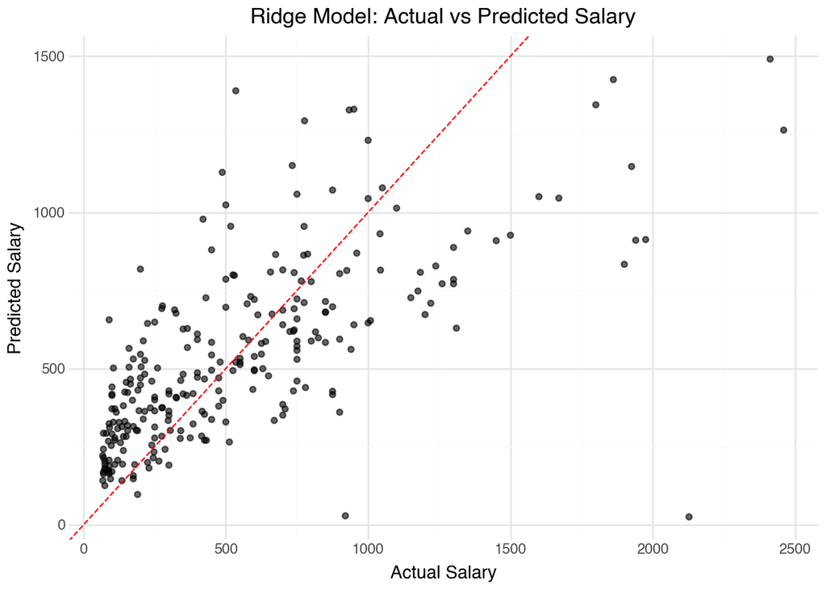

```python
from plotnine import ggplot, aes, geom_point, geom_abline, labs, theme_minimal

# Create a dataframe for plotting
import pandas as pd
plot_df = pd.DataFrame({
    "Actual": y_final,
    "Predicted": final_pred
})

# Plot with a 45-degree reference line
p = (
    ggplot(plot_df, aes(x="Actual", y="Predicted"))
    + geom_point(alpha=0.6)
    + geom_abline(intercept=0, slope=1, color="red", linetype="dashed")  # best-fit/reference line
    + labs(
        title="Ridge Model: Actual vs Predicted Salary",
        x="Actual Salary",
        y="Predicted Salary"
    )
    + theme_minimal()
)

p
```

This scatterplot shows the predicted salaries from your Ridge regression model versus the actual salaries for each player. The red dashed line represents perfect predictions—where the predicted salary equals the actual salary.